# BIEN tutorial

# Setup

```r
library(BIEN)
library(ape) #Package for working with phylogenies in R
library(maps) #Useful for making quick maps of occurrences
library(sp) # A package for spatial data
```

# An overview of the package

We try to make this package as easy and intuitive to use as possible, but it is still often easiest to start with our vignette. Particularly useful are the “Function Names” and “Function Directory” sections.

```r
vignette("BIEN")
```

The function names follow a consistent naming strategy, and mostly consist of 3 parts:

1. The prefix “BIEN_”
2. The type of data being accessed, e.g. “occurrence_”
3. How you’ll be querying the data. For example, the suffix “state” refers to functions that return data for a specified state.

As a complete example, the function `BIEN_occurrence_species` returns occurrence records for a given species (or set of species).

# Function Families

Currently we have 9 function families in RBIEN. These are sets of functions that access a given type of data.

1. occurrence records (`BIEN_occurrence_...`)
2. range maps (`BIEN_ranges_...`)
3. plot data (`BIEN_plot_...`)
4. trait data (`BIEN_trait_...`)
5. taxonomic information (`BIEN_taxonomy_...`)
6. phylogenies (`BIEN_phylogeny_...`)
7. stem data (`BIEN_stem_...`)
8. species lists (`BIEN_list_...`)
9. metadata (`BIEN_metadata_...`)

We’ll walk through each of the function families and take a look at some the options available within each.

# Occurrence records

These functions begin with the prefix `BIEN_occurrence_...` and allow you to query occurrences by either taxonomy or geography. Functions include:

1. `BIEN_occurrence_country` Returns all occurrence records within a given country
2. `BIEN_occurrence_state` Returns all occurrences records within a given state/province
3. `BIEN_occurrence_county` Returns all occurrences records within a given state/province
4. `BIEN_occurrence_family` Returns all occurrence records for a specified family
5. `BIEN_occurrence_genus` Returns all occurrence records for a specified genus
6. `BIEN_occurrence_species` Returns all occurrence records for a specified species

Each of these functions has a number of different arguments that modify your query, either refining your search criteria or returning more data for each record. These arguments include:

1. cultivated If TRUE, records known to be cultivated will be returned.
2. only.new.world If TRUE, records returned are limited to those in North and South America, where greater data cleaing and validation has been done.
- Note that the arguments cultivated and only.new.world may change the number of records returned.
3. all.taxonomy If TRUE, the query will return additional taxonomic data, including the uncorrected taxonomic information for those records.
4. native.status If TRUE, additional information will be returned regarding whether a species is native in a given region.
5. natives.only If TRUE, the default, information for occurrences flagged as introduced will not be returned.
6. observation.type If TRUE, the query will return whether each record is from either a plot or a specimen. This may be useful if a user believes one type of information may be more accurate.
7. political.boundaries If TRUE, the query will return information on which country, state, etc. that an occurrence is found within.
8. collection.info If TRUE, the quest will return additional information about the collection and identification of that specimen.

**Example 1: Occurrence records for a species**

Okay, enough reading. Let’s get some data.

Let’s say we’re interested in the species *Xanthium strumarium* and we’d like some occurrence data. We’ll use the function `BIEN_occurrence_species` to grab the occurrence data.

```r
Xanthium_strumarium <- BIEN_occurrence_species(species = "Xanthium strumarium")
```

Take a moment and view the dataframe and take a look at the structure

```r
str(Xanthium_strumarium)
```

```
## 'data.frame':    2935 obs. of  10 variables:
##  $ scrubbed_species_binomial  : chr  "Xanthium strumarium" "Xanthium strumarium" "Xanthium strumarium" "Xanthium strumarium" ...
##  $ latitude                   : num  NA 39.4 44.7 40.9 41.1 ...
##  $ longitude                  : num  NA -84.6 -93.1 -88.6 -85.5 ...
##  $ date_collected             : Date, format: NA NA ...
##  $ datasource                 : chr  "GBIF" "GBIF" "GBIF" "GBIF" ...
##  $ dataset                    : chr  "UCJEPS" "USDA NRCS" "USDA NRCS" "USDA NRCS" ...
##  $ dataowner                  : chr  "UCJEPS" "USDA NRCS" "USDA NRCS" "USDA NRCS" ...
##  $ custodial_institution_codes: chr  "UCJEPS" "USDA NRCS" "USDA NRCS" "USDA NRCS" ...
##  $ collection_code            : chr  "JEPS" "USDA Plants" "USDA Plants" "USDA Plants" ...
##  $ datasource_id              : num  1021 102 102 102 102 ...
```

```r
head(Xanthium_strumarium)
```

```
##   scrubbed_species_binomial latitude longitude date_collected datasource
## 1       Xanthium strumarium       NA        NA           <NA>       GBIF
## 2       Xanthium strumarium 39.43840 -84.57740           <NA>       GBIF
## 3       Xanthium strumarium 44.68480 -93.06482           <NA>       GBIF
## 4       Xanthium strumarium 40.88810 -88.55674           <NA>       GBIF
## 5       Xanthium strumarium 41.13542 -85.50394           <NA>       GBIF
## 6       Xanthium strumarium       NA        NA           <NA>       GBIF
##     dataset dataowner custodial_institution_codes collection_code
## 1    UCJEPS    UCJEPS                      UCJEPS            JEPS
## 2 USDA NRCS USDA NRCS                   USDA NRCS     USDA Plants
## 3 USDA NRCS USDA NRCS                   USDA NRCS     USDA Plants
## 4 USDA NRCS USDA NRCS                   USDA NRCS     USDA Plants
## 5 USDA NRCS USDA NRCS                   USDA NRCS     USDA Plants
## 6    UCJEPS    UCJEPS                      UCJEPS            JEPS
##   datasource_id
## 1          1021
## 2           102
## 3           102
## 4           102
## 5           102
## 6          1021
```

The default data that is returned consists of the latitude, longitude and date collected, along with a set of attribution data. The meaning of some of these columns is obvious (e.g. latitude, longitide), however others may be less clear. The meanings of these columns and the information within is explained in more detail in our data dictionary, available at http://bien.nceas.ucsb.edu/bien/tools/rbien/data-dictionary/

If we want more information on these occurrences, we just need to change the arguments:

```r
Xanthium_strumarium_full <- BIEN_occurrence_species(species = "Xanthium strumarium",cultivated = T,only.new.world = F,all.taxonomy = T,native.status = T,observation.type = T,political.boundaries = T)

str(Xanthium_strumarium_full)
```

```
## 'data.frame':    7719 obs. of  34 variables:
##  $ scrubbed_species_binomial   : chr  "Xanthium strumarium" "Xanthium strumarium" "Xanthium strumarium" "Xanthium strumarium" ...
##  $ verbatim_family             : chr  NA "Asteraceae" "asteraceae" NA ...
##  $ verbatim_scientific_name    : chr  "Xanthium strumarium" "Xanthium strumarium" "xanthium strumarium" "Xanthium strumarium L." ...
##  $ family_matched              : chr  "Asteraceae" "Asteraceae" "Asteraceae" "Asteraceae" ...
##  $ name_matched                : chr  "Xanthium strumarium" "Xanthium strumarium" "Xanthium strumarium" "Xanthium strumarium" ...
##  $ name_matched_author         : chr  "L." "L." "L." "L." ...
##  $ higher_plant_group          : chr  "flowering plants" "flowering plants" "flowering plants" "flowering plants" ...
##  $ scrubbed_taxonomic_status   : chr  "Accepted" "Accepted" "Accepted" "Accepted" ...
##  $ scrubbed_family             : chr  "Asteraceae" "Asteraceae" "Asteraceae" "Asteraceae" ...
##  $ scrubbed_author             : chr  "L." "L." "L." "L." ...
##  $ native_status               : chr  "UNK" "P" NA "UNK" ...
##  $ native_status_reason        : chr  "Status unknown, no checklists for region of observation" "Present in one or more checklists for region, status not indicated" NA "Status unknown, no checklists for region of observation" ...
##  $ native_status_sources       : chr  NA "usda" NA NA ...
##  $ is_introduced               : int  NA 0 NA NA 0 NA 0 NA NA NA ...
```

[output cut: 20 more lines]

We now have considerably more information.

Let’s take a quick look at where those occurrences are.

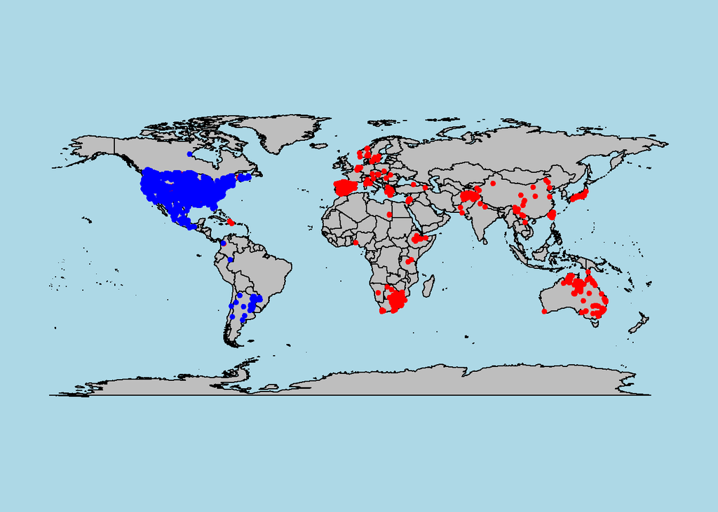

```r
# Make a quick map to plot our points on

map('world',fill=T , col= "grey", bg="light blue")

#Plot the points from the full query in red

points(cbind(Xanthium_strumarium_full$longitude,Xanthium_strumarium_full$latitude),col="red",pch=20,cex=1)

# Plot the points from the default query in blue

points(cbind(Xanthium_strumarium$longitude,Xanthium_strumarium$latitude),col="blue",pch=20,cex=1)
```

From the map, we can see that the points from the default query (in blue) all fall within the New World. The points from the full query (red + blue) additionally include occurrences from the Old World.

**Example 2: Occurrence records for a country**

Since we may be interested in a particular geographic area, rather than a particular set of species, there are also options to easily extract data by political region as well.

We’ll choose a relatively small region, the Bahamas, for our demonstration.

```r
Bahamas <- BIEN_occurrence_country(country =  "Bahamas")

#Let's see how many species we have
length(unique(Bahamas$scrubbed_species_binomial))
```

```
## [1] 948
```

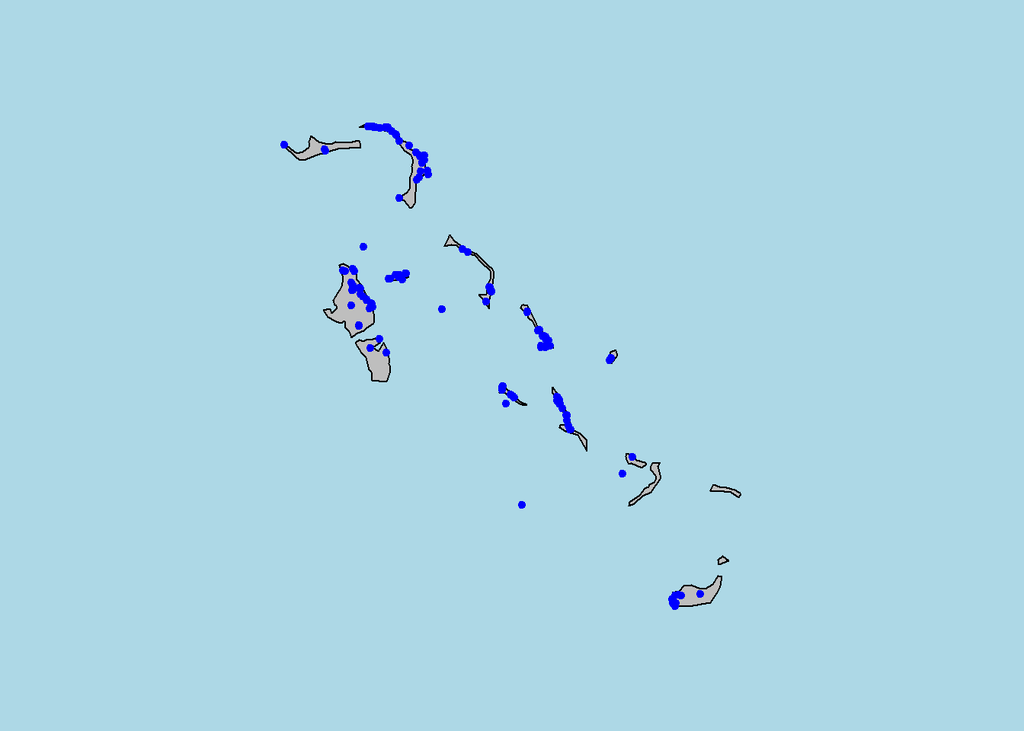

```r
#Nearly 1000 species, not bad.

#Now, let's take a look at where those occurrences are:
map(regions = "Bahamas" ,fill=T , col= "grey", bg="light blue")

points(cbind(Bahamas$longitude,Bahamas$latitude),col="blue",pch=20,cex=1)
```

```r
#Looks like some islands are considerably better sampled than others.
```

# Range maps

These functions begin with the prefix `BIEN_ranges_...` and return (unsurprisingly) species ranges. Most of these functions work by saving the downloaded ranges to a specified directory in shapefile format, rather than by loading them into the R environment.

Functions include:

1. `BIEN_ranges_species` Downloads range maps for given species and save them to a specified directory.
2. `BIEN_ranges_genus` Saves range maps for all species within a genus to a specified directory.
3. `BIEN_ranges_load_species` This function returns the ranges for a set of species as a SpatialPolygonsDataFrame object.

The range functions have different arguments than we have seen so far, including:

1. directory This is where the function will be saving the shapefiles you download
2. matched If TRUE, the function will return a dataframe listing which species ranges were downloaded and which weren’t.
3. match_names_only If TRUE, the function will check whether a map is available for each species without actually downloading it
4. include.gid If TRUE, the function will append a unique gid number to each range map’s filename. This argument is designed to allow forward compatibility when BIEN contains multiple range maps for each species.

**Example 3: Range maps and occurrence points**

If we have a species we’re interested in, and would like to load the range map into the environment, we can use the function `BIEN_ranges_load_species`. Let’s try this for *Xanthium strumarium*.

```r
Xanthium_strumarium_range <- BIEN_ranges_load_species(species = "Xanthium strumarium")
```

The range map is now in our global environment as a SpatialPolygonsDataFrame. Let’s plot the map and see what it looks like.

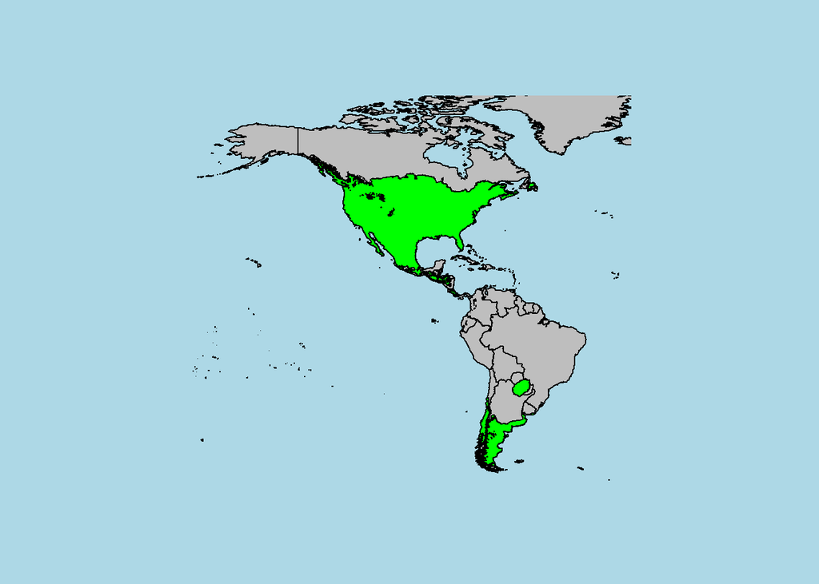

```r
#First, let's add a base map so that our range has some context:

map('world',fill=T , col= "grey", bg="light blue",xlim = c(-180,-20),ylim = c(-60,80))

#Now, we can add the range map:
plot(Xanthium_strumarium_range,col="green",add=T)
```

Now, let’s add those occurrence points from earlier to this map:

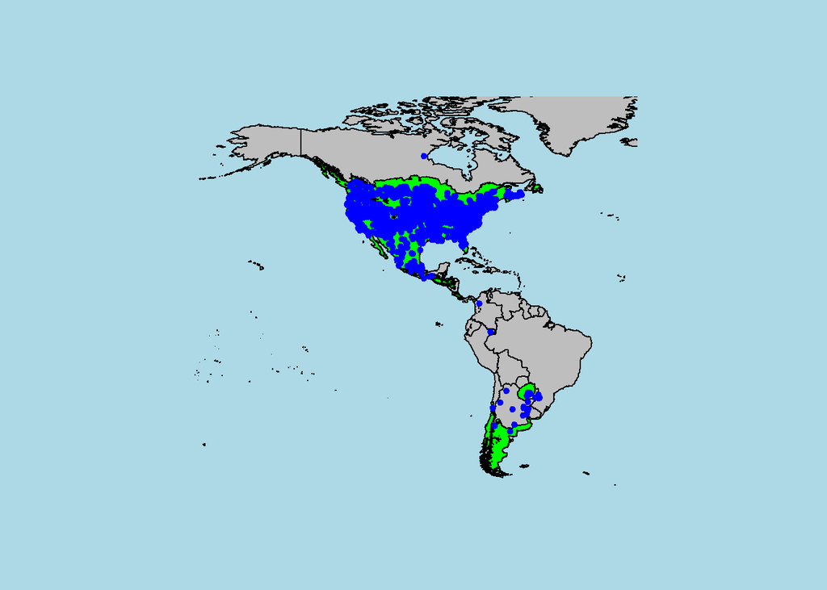

```r
map('world',fill=T , col= "grey", bg="light blue",xlim = c(-180,-20),ylim = c(-60,80))
plot(Xanthium_strumarium_range,col="green",add=T)
points(cbind(Xanthium_strumarium$longitude,Xanthium_strumarium$latitude),col="blue",pch=20,cex=1)
```

# Plot data

These functions begin with the prefix “BIEN_plot_” and return ecological plot data. Functions include:

1. `BIEN_plot_list_sampling_protocol` Returns the different plot sampling protocols found in the BIEN database.
2. `BIEN_plot_list_datasource` Returns the different datasources that are available in the BIEN database.
- These first two functions are useful for identifying plots with comparable sampling methods.
3. `BIEN_plot_sampling_protocol` Downloads data for a specified sampling protocol
4. `BIEN_plot_datasource` Downloads data for a specific datasource
- These next two function are then useful for downloading datasets with consistent methodology.
5. `BIEN_plot_country`
6. `BIEN_plot_state`
7. `BIEN_plot_dataset` Downloads data for a given dataset (which is nested within a datasource)
8. `BIEN_plot_name` Downloads data for a specific plot name (these are nested within a given dataset)

Again we have some of the same arguments available for these queries that we saw for the occurrence functions. We also have the new argument *all.metadata*, which causes the functions to return more metadata for each plot.

**Example 4: Plot data by plot name**

Let’s take a look at the data for an individual plot.

```r
LUQUILLO <- BIEN_plot_name(plot.name = "LUQUILLO")
head(LUQUILLO)
```

```
##   plot_name subplot elevation_m plot_area_ha
## 1  LUQUILLO       1         300          0.1
## 2  LUQUILLO       1         300          0.1
## 3  LUQUILLO       1         300          0.1
## 4  LUQUILLO       1         300          0.1
## 5  LUQUILLO       1         300          0.1
## 6  LUQUILLO       1         300          0.1
##                       sampling_protocol     recorded_by
## 1 0.1 ha  transect, stems >= 2.5 cm dbh Alwyn H. Gentry
## 2 0.1 ha  transect, stems >= 2.5 cm dbh Alwyn H. Gentry
## 3 0.1 ha  transect, stems >= 2.5 cm dbh Alwyn H. Gentry
## 4 0.1 ha  transect, stems >= 2.5 cm dbh            <NA>
## 5 0.1 ha  transect, stems >= 2.5 cm dbh Alwyn H. Gentry
## 6 0.1 ha  transect, stems >= 2.5 cm dbh Alwyn H. Gentry
##   scrubbed_species_binomial individual_count latitude longitude
```

[output cut: 20 more lines]

We can see that this is a 0.1 hectare transect where stems >= 2.5 cm diameter at breast height were included. If we’d like more detail, we can use additional arguments:

```r
LUQUILLO_full <- BIEN_plot_name(plot.name = "LUQUILLO",cultivated = T,all.taxonomy = T,native.status = T,political.boundaries = T,all.metadata = T)
```

The dataframe LUQUILLO_full contains more useful information, including metadata on which taxa were included, which growth forms were included and information on whether species are known to be native or introduced.

# Trait data

These functions begin with the prefix `BIEN_trait_...` and access the BIEN trait database. Note that the spelling of the trait names must be precise, so we recommend using the function `BIEN_trait_list` first. Traits names are standardized to follow http://www.top-thesaurus.org/ where available. Trait units have been standardized for each trait.

Functions include:

1. `BIEN_trait_list` Start with this. It returns a dataframe of the traits available.
2. `BIEN_trait_family` Returns a dataframe of all trait data for a given family (or families).
3. `BIEN_trait_genus`
4. `BIEN_trait_species`
5. `BIEN_trait_trait` Downloads all records of a specified trait (or traits).
6. `BIEN_trait_mean` Estimates species mean trait values using genus or family level means where species-level data is absent.
7. `BIEN_trait_traitbyfamily` Downloads data for a given family (or families) and trait(s).
8. `BIEN_trait_traitbygenus`
9. `BIEN_trait_traitbyspecies`

**Example 5: Accessing trait data**

If you’re interested in accessing all traits for a taxon, say the genus *Salix*, just go ahead and use the corresponding function:

```r
Salix_traits<-BIEN_trait_genus(genus = "Salix")
```

If instead we’re interested in a particular trait, the first step is to check if that trait is present and verify the spelling using the function `BIEN_trait_list`.

```r
BIEN_trait_list()
```

```
##                                                                                    trait_name
## 1                                                                         aboveground biomass
## 2                                                                     Aboveground stem length
## 3                                                                           acoustic velocity
## 4                                                                        active growth period
## 5                                                                                        Amax
## 6                                                                               annual growth
## 7                                                        Annual relative basal area increment
## 8                                                                        annual transpiration
## 9                                                   annual transpiration per needle unit area
## 10                                                                              anther length
## 11                                                                               anther width
## 12                                                                             bark thickness
## 13                                                                        basal stem diameter
## 14                                                                        bee visitation rate
```

[output cut: 523 more lines]

If we’re interested in leaf area, we see that this is indeed called “leaf area” in the database. Now that we know the proper spelling, we can use the function `BIEN_trait_trait` to download all observations of that trait.

```r
leaf_area <- BIEN_trait_trait(trait = "leaf area")
```

Note that the units have been standardized and that there is a full set of attribution data for each trait.

# Taxonomy Data

While there are existing packages that query taxonomic data (e.g. those included in the excellent taxize package), the RBIEN taxonomy functions access the taxonomic information that underlies the BIEN database, ensuring consistency.

1. `BIEN_taxonomy_family` Downloads all taxonomic information for a given family.
2. `BIEN_taxonomy_genus`
3. `BIEN_taxonomy_species`

**Example 6: Taxonomic data**

Let’s say we’re interested in the genus *Asclepias*, and we’d like to get an idea of how many species there are in this genus and what higher taxa it falls within.

```r
Asclepias_taxonomy<-BIEN_taxonomy_genus(genus = "Asclepias")

#We see that the genus Asclepias falls within the family Apocynaceae and the order Gentianales.

#You'll also notice that a given species may appear more than once (due to multiple circumscriptions, some of which may be illegitimate).

#If we'd just like to know all the speciess that aren't illegitimate:
Asclepias_species<-unique(Asclepias_taxonomy$scrubbed_species_binomial[Asclepias_taxonomy$scrubbed_taxonomic_status %in% c("accepted",  "no opinion")])
```

# Phylogenies

The BIEN database currently contains 101 phylogenies for new world plants. This includes 100 replicated phylogenies that include a large fraction of New World plant species (“complete phylogenies”) and 1 phylogeny containing only those New World plant species for which molecular data were available (“conservative phylogeny”). Currently, there are only 2 functions available:

1. `BIEN_phylogeny_complete` This function will return a specified number of the replicated “complete” phylogenies. Note that each phylogeny is several Mb in size, so downloading many may take a while on slow connections.
2. `BIEN_phylogeny_conservative` This function returns the conservative phylogeny.

Arguments: The function `BIEN_phylogeny_complete` has a few arguments that are worth explaining:

1. n_phylogenies This is the number of replicated phylogenies that you want to download (between 1 and 100)
2. seed This function sets the seed for the random number generator before randomly drawing the phylogenies to be downloaded. This is useful for replicating analyses.
3. replicates This function allows you to specify WHICH of the 100 phylogenies to download, rather than having them selected randomly.

**Example 7: Phylogenies**

Let’s say we want to download the conservative phylogeny.

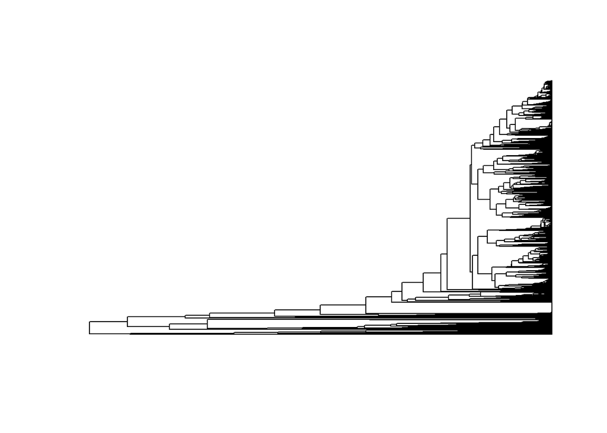

```r
phylo <- BIEN_phylogeny_conservative()

#Let's make sure it looks alright

plot.phylo(x = phylo, show.tip.label =  FALSE)
```

```r
#If we just want to see which species are included

phylo_species <- phylo$tip.label
```

# Stem Data

1. `BIEN_stem_species` This function downloads all of the stem data for a given species (or set of species)
2. `BIEN_stem_genus`
3. `BIEN_stem_family`
4. `BIEN_stem_datasource` This function downloads all of the stem data for a given datasource.

Arguments:

The arguments for this function are the same that we have seen in the occurrence and plot functions.

**Example 8: Stem data**

If we’d like stem data for the species *Cupressus arizonica*

```r
Cupressus_arizonica_stems<-BIEN_stem_species("Cupressus arizonica")
```